# Unicef Water

Belicia Rodriguez

5/10/2019

# Introduction

UNICEF collects data on the accessibility and conditions of drinking water, sanitation, and hygiene (WASH) around the world. The organization divides the evaluation for each criteria into different hierarchial evaluations.

Drinking Water

1. *Safely managed drinking water service*: Water from an improved source that is located on premises, available when needed and free from contamination.
2. *Basic drinking water service*: An improved water source within 30 minutes roundtrip
3. *Limited drinking water service*: An improved water source that takes over 30 minutes roundtrip to access
4. *Unimproved water sources*: Water source without improvement
5. *Surface water*: Water taken directly from lakes, rivers, etc

Sanitation

1. *Safely managed sanitation service*: Improved sanitation facilities not shared with other households with excreta safely disposed in situ or removed and treated offsite
2. *Basic sanitation service*: Improved sanitation facilites not shared with other households
3. *Limited sanitation service*: Improved facilities shared with other households
4. *Unimproved sanitation service*: Sanitation without improvement
5. *Open defecation*: Go out in fields, bushes, forests, open bodies of water, etc (Proportion of population using improved sanitation facilities (excluding shared))

Hygiene

1. *Basic*: Handwashing facilities with soap or water
2. *Limited*: Handwashing facilities without water or soap
3. *No facility*: No facilities for handwashing

This investigation specifically outlines the WASH accessibility and conditions of 232 countries in 2000 and 2015. In this analysis, I will be investigating which countries have low drinking water, sanitation, and/or hygiene and showing whether there has been improvement between 2000 to 2015.

I will be using the excel sheet UNICEF uploaded on [their WASH overview post](https://data.unicef.org/topic/water-and-sanitation/drinking-water/#status) in July 2017 to do an analysis on the progession of countries towards improving WASH conditions.

I analyze each evaluation through three country levels: national, urban, and rural.

1. *National*: encompasses the urban, suburban, and rural levels
2. *Urban*: refers to cities in the region and suburban areas
3. *Rural*: everything outside of urban areas

# Code Explanation

Although the investigation portion of this report will not include code, this section will breakdown the steps taken to import, clean, and tidy the data and show glimpses of code. This section will not analyze any of the data, but I decided to include this section in order to explain how the data was prepared for analysis. I’ve allowed for the code to be accessible through a “code” button on the side, but I will explain what each section will discuss.

1. Downloading Data from Website

Explain why download.file() was used to download data from UNICEF’s website, and I also breakdown what components of read_excel() were used to set up the data.

2. Tidying Data

Mainly used select(), separate(), gather(), drop_na(), mutate_at() with as.factor(), and mutate() with str_remove() to tidy the four dataframes created from the UNICEF’s excel files. I also use the drinking water and sanitation dataframes to create two dataframes containing rates on improved sanitation facilities dataframe and improved water supply.

3. Functions

## Downloading Data from Website

- download.file()

Reproductibility is an important component of creating an R Markdown report; if I shared my R Markdown document with another person who is using a different computer than mine, I want that person to be able to reproduce my document without difficulty. That is why I used download.file() to import the UNICEF excel file; on UNICEF’s website, the excel file has its own [website link](https://data.unicef.org/wp-content/uploads/2015/12/Drinking-Water-Sanitation-Hygiene-Database-July-2017.xlsx). I used the link as the main argument in download.files, which then saved the file to my computer in the same folder where my R markdown document is saved; another argument of download.files() allowed me to save the file as “unicef_water.xlsx”.

- read_excel()

```r
# Downlown unicef web file to computer
download.file("https://data.unicef.org/wp-content/uploads/2015/12/Drinking-Water-Sanitation-Hygiene-Database-July-2017.xlsx", "unicef_water.xlsx")

# Create drinking_water dataframe
drinking_water <- read_excel("unicef_water.xlsx", sheet = 1, col_names = c("iso_code", "countries", "year", "national/at_least_basic", "national/limited", "national/unimproved", "national/surface_water", "national/annual_basic_change_rate", "rural/at_least_basic", "rural/limited", "rural/unimproved", "rural/surface_water", "rural/annual_basic_change_rate", "urban/at_least_basic", "urban/limited", "urban/unimproved",  "urban/surface_water", "urban/annual_basic_change_rate", "DELETE", "national/iws_safely_managed", "national/iws_accessible_premise", "national/iws_available_needed", "national/iws_free_from_contamination", "national/iws_piped", "national/iws_non_piped", "rural/iws_safely_managed", "rural/iws_accessible_premise", "rural/iws_available_needed", "rural/iws_free_from_contamination", "rural/iws_piped", "rural/iws_non_piped", "urban/iws_safely_managed", "urban/iws_accessible_premise", "urban/iws_available_needed", "urban/iws_free_from_contamination", "urban/iws_piped", "urban/iws_non_piped"), na = "-", skip = 7, n_max = 464)

# Delete empty column in drinking_water
drinking_water <- subset(drinking_water, select = -DELETE)

# Create sanitation dataframe
sanitation <- read_excel("~/Downloads/Drinking-Water-Sanitation-Hygiene-Database-July-2017.xlsx", sheet = 2, col_names = c("iso_code", "countries", "year", "national/at_least_basic", "national/limited_shared", "national/unimproved", "national/open_defecation",  "national/annual_rate_change_basic", "national/annual_rate_change_open_defecation", "rural/at_least_basic", "rural/limited_shared", "rural/unimproved", "rural/open_defecation", "rural/annual_rate_change_basic", "rural/annual_rate_change_open_defecation", "urban/at_least_basic", "urban/limited_shared", "urban/unimproved", "urban/open_defecation", "urban/annual_rate_change_basic", "urban/annual_rate_change_open_defecation", "DELETE", "national/isf_safely_managed", "national/isf_disposed_situ", "national/isf_emptied_treated", "national/isf_wastewater_treated", "national/isf_latrines_and_other", "national/isf_septic_tanks", "national/isf_sewer_connections",   "rural/isf_safely_managed", "rural/isf_disposed_situ", "rural/isf_emptied_treated", "rural/isf_wastewater_treated", "rural/isf_latrines_and_other", "rural/isf_septic_tanks", "rural/isf_sewer_connections", "urban/isf_safely_managed", "urban/isf_disposed_situ", "urban/isf_emptied_and_treated", "urban/isf_wastewater_treated", "urban/isf_latrines_and_other", "urban/isf_septic_tanks", "urban/isf_sewer_connections"), na = "-", skip = 8, n_max = 464)

# Delete empty column in sanitation
sanitation <- subset(sanitation, select = -DELETE)

# Create hygiene dataframe
hygiene <- read_excel("~/Downloads/Drinking-Water-Sanitation-Hygiene-Database-July-2017.xlsx", sheet = 3, col_names = c("iso_code", "countries", "year", "national/basic", "national/limited", "national/no_facility", "rural/basic", "rural/limited", "rural/no_facility", "urban/basic", "urban/limited", "urban/no_facility"), na = "-", skip = 7, n_max = 71)
```

*After using download.file() and read_excel(), the dataframes were formatted this way.*

| iso_code | countries | year | national/at_least_basic | national/limited | national/unimproved | national/surface_water | national/annual_basic_change_rate | rural/at_least_basic | rural/limited | rural/unimproved | rural/surface_water | rural/annual_basic_change_rate | urban/at_least_basic | urban/limited | urban/unimproved | urban/surface_water | urban/annual_basic_change_rate | national/iws_safely_managed | national/iws_accessible_premise | national/iws_available_needed | national/iws_free_from_contamination | national/iws_piped | national/iws_non_piped | rural/iws_safely_managed | rural/iws_accessible_premise | rural/iws_available_needed | rural/iws_free_from_contamination | rural/iws_piped | rural/iws_non_piped | … |
| --- | --- | --- | --- | --- | --- | --- | --- | --- | --- | --- | --- | --- | --- | --- | --- | --- | --- | --- | --- | --- | --- | --- | --- | --- | --- | --- | --- | --- | --- | --- |
| AFG | Afghanistan | 2000 | 27.06986 | 2.36331358 | 46.308016747 | 2.425881e+01 | 2.394023e+00 | 20.920631 | 2.32580606 | 48.764806087 | 27.988756578 | 2.1708352566 | 49.81466 | 2.50204665 | 37.220828360 | 1.046246e+01 | 2.615598e+00 | NA | 14.346011 | NA | NA | 6.145233 | 23.287939884 | NA | 7.96236972 | NA | NA | 2.1268825 | 2.111955e+01 | … |
| AFG | Afghanistan | 2015 | 62.98021 | 5.55248124 | 16.304966756 | 1.516234e+01 | 2.394023e+00 | 53.483161 | 5.94587509 | 20.199573315 | 20.371390286 | 2.1708352566 | 89.04863 | 4.47265542 | 5.614670647 | 8.640452e-01 | 2.615598e+00 | NA | 39.589371 | NA | NA | 12.199350 | 56.333339573 | NA | 26.32825171 | NA | NA | 5.5473771 | 5.388166e+01 | … |
| ALB | Albania | 2000 | 87.58479 | 9.26840245 | 2.000665720 | 1.146137e+00 | 2.539692e-01 | 81.827788 | 12.77081078 | 3.434088673 | 1.967312925 | 0.5364924073 | 95.62000 | 4.38000000 | 0.000000000 | 0.000000e+00 | -2.065687e-01 | 43.235267 | 61.281688 | 49.29324 | 96.179516 | 76.205173 | 20.648024382 | NA | 39.19976721 | 53.422641 | NA | 61.9254200 | 3.267318e+01 | … |
| ALB | Albania | 2015 | 91.39433 | 4.74114762 | 3.864519217 | 0.000000e+00 | 2.539692e-01 | 89.875174 | 5.41920048 | 4.705625634 | 0.000000000 | 0.5364924073 | 92.52147 | 4.23806776 | 3.240462122 | 0.000000e+00 | -2.065687e-01 | 68.869979 | 89.107362 | 69.94341 | 88.187267 | 85.972994 | 10.162486710 | NA | 89.87517388 | 67.626812 | NA | 77.3689005 | 1.792547e+01 | … |
| DZA | Algeria | 2000 | 89.83726 | 5.50481409 | 4.197200517 | 4.607290e-01 | 2.419447e-01 | 83.322006 | 8.21144636 | 7.466547816 | 1.000000000 | 0.3579300344 | 94.19544 | 3.69429441 | 2.010269675 | 1.000000e-01 | 8.316644e-02 | NA | 68.890626 | NA | NA | 80.555012 | 14.787058161 | NA | 49.97726489 | NA | NA | 66.9590246 | 2.457443e+01 | … |
| DZA | Algeria | 2015 | 93.46643 | 5.20609188 | 1.132907289 | 1.945743e-01 | 2.419447e-01 | 88.690957 | 8.74056049 | 2.145406078 | 0.423076923 | 0.3579300344 | 95.44293 | 3.74322056 | 0.713847001 | 1.000000e-01 | 8.316644e-02 | NA | 81.072447 | NA | NA | 76.534907 | 22.137611096 | NA | 74.10849956 | NA | NA | 63.6253920 | 3.380613e+01 | … |
| ASM | American Samoa | 2000 | 98.50000 | NA | 1.500000000 | 0.000000e+00 | 4.877600e-02 | NA | NA | NA | NA | NA | NA | NA | NA | NA | NA | NA | 78.200000 | NA | NA | 97.100000 | 1.400000000 | NA | NA | NA | NA | NA | NA | … |
| ASM | American Samoa | 2015 | 99.23164 | NA | 0.768360000 | 0.000000e+00 | 4.877600e-02 | NA | NA | NA | NA | NA | NA | NA | NA | NA | NA | NA | 90.958785 | NA | NA | 98.645600 | 0.586040000 | NA | NA | NA | NA | NA | NA | … |
| AND | Andorra | 2000 | 100.00000 | NA | 0.000000000 | 0.000000e+00 | 0.000000e+00 | 100.000000 | NA | 0.000000000 | 0.000000000 | 0.0000000000 | 100.00000 | NA | 0.000000000 | 0.000000e+00 | 0.000000e+00 | NA | 100.000000 | NA | NA | 100.000000 | 0.000000000 | NA | 100.00000000 | NA | NA | 100.0000000 | 0.000000e+00 | … |
| AND | Andorra | 2015 | 100.00000 | NA | 0.000000000 | 0.000000e+00 | 0.000000e+00 | 100.000000 | NA | 0.000000000 | 0.000000000 | 0.0000000000 | 100.00000 | NA | 0.000000000 | 0.000000e+00 | 0.000000e+00 | NA | 100.000000 | NA | NA | 100.000000 | 0.000000000 | NA | 100.00000000 | NA | NA | 100.0000000 | 0.000000e+00 | … |

[output cut: 454 more lines]

## Tidying Data

Tidying these dataframes created the biggest chunk of code in my report; however, the process was usually a variation of a repetition of several core steps. I will explain the core steps here.

*Drinking Water, Sanitation, Hygiene, Improved*

- Separating dataframes

Both the drinking water and sanitation dataframes have data on the improvement of both facility categories, and I decided it was best to create new dataframes that focused solely on improvement. For drinking water, I created an improved_water_supply object and assigned variables that only contained “iws” and the other important variables (percentage, countries, iso_code, year). I then deleted the “iws” variables from the drinking_water dataframe. The same process was done for the sanitation/improved_sanitation_facilities dataframes.

- Gather & separate columns

An important component of tidying data is that every row has to represent an observation and columns have to be variable names (not values). Therefore, I decided to gather “national/at_least_basic” to “urban/annual_basic_change_rate” columns and create two new columns: evaluation, containing the old column names, and percentage, containing all the percentages that were underneath the columns.

After gathering, I separated the evaluation columns, which has the “national/at_least_basic” to “urban/annual_basic_change_rate” names in them, by the “/” in each of the names. The separation created two columns: country_level (national, rural, urban) and water_supply (at_least_basic, limited, etc).

- Remove rows with NAs

Now that each row is an observation, I can remove the rows that have no observation, or simply NA in their percentage column. This is done by using the drop_na() function.

- Creating categorical variables

There are three categorical variables in each dataframe: country_level (national, urban, rural), level/improvement (at least basic, limited, etc), and year (2000, 2015). I made them categorical variables in order to make it easier to investigate the data in later graphs and tables.

- Round percentage variable

The percentage columns had more than 8-10 digits in each column, so I decided to set the cap at the number of digits to 6 in order to read the numbers with more ease.

- Snip

Specifically for the improved_water_supply and improved_sanitation_facilities, the improvement values all had either “iws” or “isf” in the name. These letters were no longer necessary; therefore, I snipped them from the values using mutate() and str_remove().

```r
## Separate Dataframes
# Drinking Water -> Drinking Water and Improved Water Supply
improved_water_supply <- drinking_water %>% select(iso_code, countries, year, contains("iws"))
drinking_water <- drinking_water %>% select(-contains("iws"))

# Sanitation -> Sanitation and Improved Sanitation Facilities
improved_sanitation_facilities <- sanitation %>% select(iso_code, countries, year, contains("isf"))
sanitation <- sanitation %>% select(-contains("isf") )

## Drinking Water Dataframe
# Gather columns
drinking_water <- gather(drinking_water, evaluation, percentage, "national/at_least_basic":"urban/annual_basic_change_rate")

# Separate evaluation column
drinking_water <- separate(drinking_water, evaluation, c("country_level", "water_supply"), sep = "/")

# Remove rows with NAs
drinking_water <- drop_na(drinking_water)

# change country_level, water_supply, and year into categorical variables
drinking_water <- drinking_water %>% mutate_at(c("country_level","water_supply","year"), as.factor)

# Round percentage variable to six digits
drinking_water <- drinking_water %>% mutate(percentage = round(drinking_water$percentage, digits = 6))

## Improved Water Supply Dataframe
# Gather columns
improved_water_supply <- gather(improved_water_supply, evaluation, percentage, "national/iws_safely_managed":"urban/iws_non_piped")

# Separate evaluation column
improved_water_supply <- separate(improved_water_supply, evaluation, c("country_level", "water_improvement"), sep = "/")

# Remove rows with NAs
improved_water_supply <- drop_na(improved_water_supply)

# snip iws from water_improvement variable
improved_water_supply <- improved_water_supply %>% mutate(water_improvement = str_remove(water_improvement, "iws_"))

# change country_level, water_improvement, and years into categorical variables
improved_water_supply <- improved_water_supply %>% mutate_at(c("country_level", "water_improvement", "year"), as.factor)

# Round percentage variable to six digits
improved_water_supply <- improved_water_supply %>% mutate(percentage = round(improved_water_supply$percentage, digits = 6))

## Hygiene Dataframe
# Gather columns
hygiene <- gather(hygiene, evaluation, percentage, "national/basic":"urban/no_facility")

# Separate evaluation column
hygiene <- separate(hygiene, evaluation, c("country_level", "hygiene_level"), sep = "/")

# Remove rows with NAs
hygiene <- drop_na(hygiene)

# change country_level, hygiene_level, and year to categorical variables
hygiene <- hygiene %>% mutate_at(c("country_level", "hygiene_level", "year"), as.factor)

# Round percentage variable to six digits
hygiene <- hygiene %>% mutate(percentage = round(hygiene$percentage, digits = 6))

## Sanitation Dataframe
# Gather columns
sanitation <- gather(sanitation, evaluation, percentage, "national/at_least_basic":"urban/annual_rate_change_open_defecation")

# Separate evaluation column
sanitation <- separate(sanitation, evaluation, c("country_level", "sanitation_level"), sep = "/")

# Remove rows with NAs
sanitation <- drop_na(sanitation)

# Change country_level, sanitation_level, and year to categorical variables
sanitation <- sanitation %>% mutate_at(c("country_level", "sanitation_level", "year"), as.factor)

# Round percentage variable to six digits
sanitation <- sanitation %>% mutate(percentage = round(sanitation$percentage, digits = 6))

## Improved Sanitation Facilities
# Gather columns
improved_sanitation_facilities <- gather(improved_sanitation_facilities, evaluation, percentage, "national/isf_safely_managed":"urban/isf_sewer_connections")

# Separate evaluation columns
improved_sanitation_facilities <- separate(improved_sanitation_facilities, evaluation, c("country_level", "sanitation_improvement"), sep = "/")

# Remove rows with NAs
improved_sanitation_facilities <- drop_na(improved_sanitation_facilities)

# snip isf from sanitation_improvement column
improved_sanitation_facilities <- improved_sanitation_facilities %>% mutate(sanitation_improvement = str_remove(sanitation_improvement, "isf_"))

# Change country_level, sanitation_improvement, and year to categorical variables
improved_sanitation_facilities <- improved_sanitation_facilities %>% mutate_at(c("country_level", "sanitation_improvement", "year"), as.factor)
```

*After tidying, the drinking water dataframe was formatted this way.*

| iso_code | countries | year | country_level | water_supply | percentage |
| --- | --- | --- | --- | --- | --- |
| AFG | Afghanistan | 2000 | national | at_least_basic | 27.069859 |
| AFG | Afghanistan | 2015 | national | at_least_basic | 62.980208 |
| ALB | Albania | 2000 | national | at_least_basic | 87.584795 |
| ALB | Albania | 2015 | national | at_least_basic | 91.394333 |
| DZA | Algeria | 2000 | national | at_least_basic | 89.837256 |
| DZA | Algeria | 2015 | national | at_least_basic | 93.466427 |
| ASM | American Samoa | 2000 | national | at_least_basic | 98.500000 |
| ASM | American Samoa | 2015 | national | at_least_basic | 99.231640 |
| AND | Andorra | 2000 | national | at_least_basic | 100.000000 |
| AND | Andorra | 2015 | national | at_least_basic | 100.000000 |

[output cut: 5207 more lines]

*Rates*

- Two separate dataframes
1. Drinking Water

By using filter() and select(), I obtained only the observations that included “annual_basic_change_rate.” I also changed the variable name “water supply” to “change rates” and dropped the levels that I removed when only selecting rate values (i.e at least basic, limited, etc). I also changed the name “annual_basic_change_rate” to “drinking_water_basic” by using fct_recode().

2. Sanitation

Since the sanitation dataframe contained I used rbind() to combine the sanitation dataframe filtered by “annual_rate_change_open_defecation” AND the sanitation dataframe filtered by “annual_rate_change_basic”. Afterwards, I used mutate() to droplevels() and change the variable name “sanitation_level” to “change rates.”

- Bind two dataframes & remove from global environment

After creating rates1 (from drinking water) and rates2 (from sanitation), I used rbind() to combine the two dataframes into one, titled “annual_rate_change.” I then removed rates1 and rates2 using rm() since I don’t like my global environment cluttered with unused dataframes.

- Remove duplicate rows

- Remove rows in drinking water & sanitation

Now that I created an “annual_rate_change” dataframe, the same data that is in drinking water and sanitation dataframes can be removed. I used subset to remove the observations from the two dataframes and used droplevels() to removed unused levels.

```r
## Rates Dataframe: drinking water and sanitation annual rate changes for certain water/sanitation conditions
# Create rates1: contains drinking_water rate values
rates1 <- drinking_water %>% filter(water_supply == "annual_basic_change_rate") %>% mutate(change_rates = water_supply) %>% select(-water_supply) %>% mutate(change_rates = droplevels(change_rates))

# Recode factor name for drinking_water's rate values
rates1$change_rates <- fct_recode(rates1$change_rates, "drinking_water_basic" = "annual_basic_change_rate")

# Create rates2: contains sanitation rate values
rates2 <-rbind(sanitation %>% filter(sanitation_level == "annual_rate_change_open_defecation"), sanitation %>% filter(sanitation_level == "annual_rate_change_basic")) %>% mutate(sanitation_level = droplevels(sanitation_level)) %>% mutate(change_rates = sanitation_level) %>% select(-sanitation_level)

# Recode factor names for sanitation's rate values
rates2$change_rates <- fct_recode(rates2$change_rates, "sanitation_basic" = "annual_rate_change_basic", "sanitation_open_defecation" = "annual_rate_change_open_defecation")

# Bind rates1 and rates2 into a single dataframe
annual_rate_change <- rbind(rates1, rates2)

# Remove rates1 and rates2 from global environment
rm(rates1, rates2)

# Remove duplicate rows
annual_rate_change <- annual_rate_change %>% subset(year == 2000) %>% select(-year)

# Remove rates from drinking_water & sanitation
drinking_water <- drinking_water %>% subset(water_supply != "annual_basic_change_rate") %>% mutate(water_supply = droplevels(water_supply))

sanitation <- sanitation %>% subset(sanitation_level != "annual_rate_change_basic" & sanitation_level != "annual_rate_change_open_defecation") %>% mutate(sanitation_level = droplevels(sanitation_level))
```

*After tidying, the annual rates change dataframe was formatted this way.*

| iso_code | countries | country_level | percentage | change_rates |
| --- | --- | --- | --- | --- |
| AFG | Afghanistan | national | 2.394023 | drinking_water_basic |
| ALB | Albania | national | 0.253969 | drinking_water_basic |
| DZA | Algeria | national | 0.241945 | drinking_water_basic |
| ASM | American Samoa | national | 0.048776 | drinking_water_basic |
| AND | Andorra | national | 0.000000 | drinking_water_basic |
| AGO | Angola | national | 0.215823 | drinking_water_basic |
| AIA | Anguilla | national | 0.368333 | drinking_water_basic |
| ATG | Antigua and Barbuda | national | -0.100972 | drinking_water_basic |
| ARG | Argentina | national | 0.041048 | drinking_water_basic |
| ARM | Armenia | national | 0.203353 | drinking_water_basic |

[output cut: 1596 more lines]

## Functions

Most of the functions I created were to reduce the amount of times I’d copy and paste codes that made graphs or tables. However, the add_UN_regions() function added two categorical variables to the datasets in order to paint a bigger picture about the information in the datasets. The retrieve_data() reduced the amount of code that would be embedded into the text under each section of this report and make it easier for me to read when typing.

*add_UN_regions(df)*

This functino adds two categorical variables to the dataframes.

1. Regions 2. Least Developed Country:

I used the region designations in the [Sustainable Development Goals](https://unstats.un.org/sdgs/indicators/regional-groups/) (SDG) that were used in the 2017 Report and Statistical annex. Several graphs on the UNICEF’s WASH website had used these groupings.

- **Created a vector of countries for each region**: I copied and reformatted all of the countries in each region and assigned them to their own R object.
- **Created an empty regions and LDC (least developed country) column**: I used mutate() to create a regions column filled with NAs and a LDC column filled with FALSE.
- **Created a list with regions**: I created a regions object that was a list where each component was a region vector with its countries, which was created previously.
- **For loop**: There are three for loops nested within themselves; one for loop goes through each region, another for loop goes through each country in each region
  1. Regions for loop:

  The first for loop goes through each region in the regions list created earlier.
  2. Countries for loop:

  The second loop goes through each country in whichever region is chosen in the previous loop. This loop also matches which rows in the dataframe has the country the loop is on. This is done by having the country (c) variable equal the dataframe country column, then using as.numeric and saving this result to the row_matches album. The row_matches object is then used in the next for loop to match the region to the correct row.
  3. Rows for loop:

  The third for loop goes through every row in the dataframe and adds the correct region designation to the country that is in that region. The result fills up the regions column or LDC column that was added to the dataframe earlier.

  There’s an if else statement in the loop that decides whether the region would be one of the seven (sub_saharan_africa, northern_africa_western_asia, central_southern_asia, eastern_southeastern_asia, latin_america_caribbean, oceania, europe_northern_america) or LDC (least_developed_countries). This is determined by the region_id_number, which is a variable defined at the beginning of all the for loops. Plus one is added to region_id_number at the end of the first for loop in order to count which region the loop is on.

  If the region_id_number equals 8, meaning the regions loop is on the least_developed_countries object, then the function begins deciding whether a row in the dataframe has a country that is on the least developed countries list. If a country is on the list, then TRUE replaces the FALSE that is already in the column.
- **Make region and LDC columns categorical variables**: This is done by using mutate_at() and as.factor on the two columns.
- **End of function**: After the function is created, I use the function on each individual dataframe and reassign the dataframe returned in the function to the dataframe in the global environment in order for it to be updated.

```r
# sustainable development goals (sdg) regional groupings
add_UN_regions <- function(df) {
  # vector of countries and their regions (total: 240)
    sub_saharan_africa <- c("Angola", "Benin", "Botswana", "Burkina Faso", "Burundi", "Cabo Verde", "Cameroon", "Central African Republic", "Chad", "Comoros", "Congo", "Côte d'Ivoire", "Democratic Republic of the Congo", "Djibouti", "Equatorial Guinea", "Eritrea", "Ethiopia", "Gabon", "Gambia", "Ghana", "Guinea", "Guinea-Bissau", "Kenya", "Lesotho", "Liberia", "Madagascar", "Malawi", "Mali", "Mauritania", "Mauritius", "Mayotte", "Mozambique", "Namibia", "Niger", "Nigeria", "Réunion", "Rwanda", "Sao Tome and Principe", "Senegal", "Seychelles", "Sierra Leone", "Somalia", "South Africa", "South Sudan", "Swaziland", "Togo", "Uganda", "United Republic of Tanzania", "Zambia", "Zimbabwe") #50

    northern_africa_western_asia <- c("Algeria", "Egypt", "Libya", "Morocco", "Sudan", "Tunisia", "Western Sahara", "Azerbaijan", "Armenia", "Bahrain", "Cyprus", "Georgia", "Iraq", "Israel", "Jordan", "Kuwait", "Lebanon", "State of Palestine", "Oman", "Qatar", "Saudi Arabia", "Syrian Arab Republic", "Turkey", "United Arab Emirates", "Yemen", "Saint Helena", "West Bank and Gaza Strip") #27

    central_southern_asia <- c("Kazakhstan", "Kyrgyzstan", "Tajikistan", "Turkmenistan", "Uzbekistan", "Afghanistan", "Bangladesh", "Bhutan", "India", "Iran (Islamic Republic of)", "Maldives", "Nepal", "Pakistan", "Sri Lanka") #14

    eastern_southeastern_asia <- c("China", "China, Hong Kong Special Administrative Region", "China, Macao Special Administrative Region", "Democratic People's Republic of Korea", "Japan", "Mongolia", "Republic of Korea", "Brunei Darussalam", "Cambodia", "Indonesia", "Lao People's Democratic Republic", "Malaysia", "Myanmar", "Philippines", "Singapore", "Thailand", "Timor-Leste", "Viet Nam") #18

    latin_america_caribbean <- c("Anguilla", "Antigua and Barbuda", "Aruba", "Bahamas", "Barbados", "Bonaire, Sint Eustatius and Saba", "British Virgin Islands", "Cayman Islands", "Cuba", "Curaçao", "Dominica", "Dominican Republic", "Grenada", "Guadeloupe", "Haiti", "Jamaica", "Martinique", "Montserrat", "Puerto Rico", "Saint Kitts and Nevis", "Saint Lucia", "Saint Vincent and the Grenadines", "Sint Maarten (Dutch part)", "Suriname", "Trinidad and Tobago", "Turks and Caicos Islands", "United States Virgin Islands", "Honduras", "Costa Rica", "El Salvador", "Guatemala", "Mexico", "Nicaragua", "Panama", "Argentina", "Belize", "Bolivia (Plurinational State of)", "Brazil", "Chile", "Colombia", "Ecuador", "French Guiana", "Falkland Islands (Malvinas)", "South Georgia & the South Sandwich Islands", "Guyana", "Paraguay", "Peru", "Uruguay", "Venezuela (Bolivarian Republic of)") #49

    oceania <- c("Australia","Christmas Island", "Cocos (Keeling) Islands", "Heard Island & McDonald Islands", "Norfolk Island", "New Zealand", "Fiji", "New Caledonia", "Papua New Guinea", "Solomon Islands", "Vanuatu", "Kiribati", "Marshall Islands", "Micronesia (Federated States of)", "Nauru", "Northern Mariana Islands", "Palau", "Guam", "French Polynesia", "Wallis and Futuna Island", "Pitcairn", "Cook Islands", "Niue", "Tokelau", "Tonga", "Tuvalu", "American Samoa", "Samoa", "Wallis and Futuna Islands") #29

    europe_northern_america <- c("Bermuda", "Canada", "Greenland", "United States of America", "Bulgaria", "Belarus", "Czech Republic", "Hungary", "Republic of Moldova", "Poland", "Romania", "Russian Federation", "Slovakia", "Ukraine", "Åland Islands", "Channel Islands", "Denmark", "Estonia","Faroe Islands", "Finland", "Isle of Man", "United Kingdom", "Iceland", "Ireland", "Latvia", "Lithuania", "Norway", "Sweden", "Albania", "Andorra", "Bosnia and Herzegovina", "Croatia", "Greece", "Italy", "Malta",  "Montenegro", "Portugal", "San Marino", "Serbia", "Slovenia", "Spain", "Gibraltar" ,"The former Yugoslav Republic of Macedonia", "Austria", "Belgium", "Switzerland", "Germany", "France", "Liechtenstein", "Luxembourg", "Monaco", "Netherlands", "Saint Pierre and Miquelon") #53

    least_developed_countries <- c("Afghanistan", "Angola", "Bangladesh", "Benin", "Bhutan", "Burkina Faso", "Burundi", "Cambodia", "Central African Republic", "Chad", "Comoros", "Democratic Republic of the Congo", "Djibouti", "Equatorial Guinea", "Eritrea", "Ethiopia", "Gambia", "Guinea", "Guinea-Bissau", "Haiti", "Kiribati", "Lao People's Democratic Republic", "Lesotho", "Liberia", "Madagascar", "Malawi", "Mali", "Mauritania", "Mozambique", "Myanmar", "Nepal", "Niger", "Rwanda", "Sao Tome and Principe", "Senegal", "Sierra Leone", "Solomon Islands", "Somalia", "Sudan", "South Sudan", "Timor-Leste", "Togo", "Tuvalu", "Uganda", "United Republic of Tanzania", "Vanuatu", "Yemen", "Zambia") #48

  # add region & LDC variables to dataframe
  df <- df %>% mutate(region = NA_character_, LDC = FALSE)

  # creating list with regions
  regions <- list(sub_saharan_africa = sub_saharan_africa, northern_africa_western_asia = northern_africa_western_asia, central_southern_asia = central_southern_asia, eastern_southeastern_asia = eastern_southeastern_asia, latin_america_caribbean = latin_america_caribbean, oceania = oceania, europe_northern_america = europe_northern_america, least_developed_countries = least_developed_countries)

  # loop for dataframe to have each country checked against the 6 regions
  region_id_number = 1
  for (r in regions) {
    # loop for individual region to be evaluated against every country in dataframe
    for (c in r) {
      # which rows match the specific region
      row_matches <- as.numeric(c == df[["countries"]])
      # go through each row and add region name if there's a match
      for (n in 1:nrow(df)) {
        if (region_id_number == 8) {
          if (row_matches[n] == 1) {
            df$LDC[n] <- TRUE
          }
        }
        else if (row_matches[n] == 1) {
          df$region[n] <- names(regions)[region_id_number]
        }
      }
    }
  # add to region id number for naming
    region_id_number = region_id_number + 1
  }

   # make region & LDC variable a categorical variable
    df <- df %>% mutate_at(c("region", "LDC"), as.factor)

  # return new df
  return(df)
}

# add regions from UN website
annual_rate_change <- add_UN_regions(annual_rate_change)
drinking_water <- add_UN_regions(drinking_water)
hygiene <- add_UN_regions(hygiene)
improved_sanitation_facilities <- add_UN_regions(improved_sanitation_facilities)
improved_water_supply <- add_UN_regions(improved_water_supply)
sanitation <- add_UN_regions(sanitation)
```

*After using the add_UN_regions(), the drinking water dataframe was formatted this way.*

| iso_code | countries | year | country_level | water_supply | percentage | region | LDC |
| --- | --- | --- | --- | --- | --- | --- | --- |
| AFG | Afghanistan | 2000 | national | at_least_basic | 27.069859 | central_southern_asia | TRUE |
| AFG | Afghanistan | 2015 | national | at_least_basic | 62.980208 | central_southern_asia | TRUE |
| ALB | Albania | 2000 | national | at_least_basic | 87.584795 | europe_northern_america | FALSE |
| ALB | Albania | 2015 | national | at_least_basic | 91.394333 | europe_northern_america | FALSE |
| DZA | Algeria | 2000 | national | at_least_basic | 89.837256 | northern_africa_western_asia | FALSE |
| DZA | Algeria | 2015 | national | at_least_basic | 93.466427 | northern_africa_western_asia | FALSE |
| ASM | American Samoa | 2000 | national | at_least_basic | 98.500000 | oceania | FALSE |
| ASM | American Samoa | 2015 | national | at_least_basic | 99.231640 | oceania | FALSE |
| AND | Andorra | 2000 | national | at_least_basic | 100.000000 | europe_northern_america | FALSE |
| AND | Andorra | 2015 | national | at_least_basic | 100.000000 | europe_northern_america | FALSE |

[output cut: 4123 more lines]

*unicef_summary_table(df, ws, yr, country, title = NA, colnames = c(NA))*

*unicef_two_tables(dataframe, water, country_level, title_name)*

*retrieve_data(df, ws, country, yr = NA, reg = NA, column = FALSE)*

- Embedding lines of R code into my text prevents me from having to look at my table and copy and paste the summary statistics into my texts (and possibly copying down the wrong number). However, the r embedded code got increasingly complicated to write because of the amount of filtering required to get the dataframe I want. Therefore, I created the retrieve_data() function to help decrease the amount of code in my texts.
- Occassionally, I may not want to specify the region or year for my dataframe; I may want all of the regions’ percentages when calculating statistics or I may want percentages form both 2000 and 2015. Therefore, I made the region and year arguments optional, and I added several if else statements that signify what to do if either, both, or neither were specified.
- I may want the function to return either a dataframe or the percentage column of the dataframe. Therefore, I created an if else statement that evaluated what to do if the column was either TRUE or FALSE. If column is TRUE, then the percentage column is returned. If FALSE, then the dataframe is returned.

*water_supply_graph(df, ws, title_name)*

- This function creates similar boxplot graphs using ggplot2; the only difference is the specified dataframe, water supply, and title name. I will explain the layers of the graph by function.
- scale_x_discrete() was used to name the x axis (“Region”) and rename the labels of each region, which makes the region label names look better instead of having the names of the variables that contain underscores and lowercase letters.
- labs() gave the graph a title (which was set by the function’s title_name argument) and a pre-set subtitle and y axis title. The x axis title was set in the scale_x_discrete() function.
- geom_boxplot() creates the boxplot graph.
- facet_grid() splits the graph’s data into panels defined by two categorical variables. For these graphs specifically, horizontally, the graphs were divided by the country_level variable, whereas vertically the graphs were separated by the year variable. I used the labeller argument to capitalize the level names for the country_level. The ggplot2 R documentation says facet_grid() “forms a matrix of panels defined by row and column faceting variables” and is most useful when “all combinations of the [discete] variables exist in the data.”
- theme_minimal() was one of the pre-set theme options I chose for my graphs. I used [this website](http://www.sthda.com/english/wiki/ggplot2-themes-and-background-colors-the-3-elements#theme_economist-theme-based-on-the-plots-in-the-economist-magazine) to browse for a theme that I wanted.
- coord_flip() flipped the x and y axis so that regions was now on the y axis and percentage was on the x axis. I wanted to do this in the aes() function, but the graphs did not turn out correctly. It was easier to flip the x and y axis at the end.

*ldc_graph(df, ws, title_text)*

- There are only a couple of differences between the water_supply_graph() function and this function. The main difference is that the x argument in aes() is LDC and not region. There is no scale_x_discrete() because the tick marks (which were TRUE and FALSE in ldc_graph) didn’t need to be renamed. There is also no subtitle. Everything else about water_supply_graph() and ldc_graph() is identical.

*outliers_region*

```r
# function to make tables
unicef_summary_table <- function(df, ws, yr, country, title = NA, colnames = c(NA)) {
  # dataframe with filter
  dtfr <- df %>% filter(water_supply == ws & year == yr & country_level == country) %>% select(region, percentage)
  ldc <- df %>% filter(LDC == TRUE & water_supply == ws & country_level == country & year == yr) %>% select(region, percentage)
  non_ldc <- df %>% filter(LDC == FALSE & water_supply == ws & country_level == country & year == yr) %>% select(region, percentage)

  # summary stats to take from dataframe
  summarystats <- list(
    table_name =
    list("Minimum" = ~ round(min(.data$percentage), 2),
         "Maximum" = ~ round(max(.data$percentage), 2),
         "Median (QR1,QR3)" = ~ qwraps2::median_iqr(.data$percentage),
         "IQR" = ~ round(IQR(.data$percentage), 2),
         "Mean (SD)" = ~ qwraps2::mean_sd(.data$percentage)
    ))

  names(summarystats) <- as.character(yr)

  # create table
  world <- summary_table(dtfr, summarystats)
  obj <- summary_table(dtfr %>% dplyr::group_by(region), summarystats)
  obj_ldc <- summary_table(ldc, summarystats)
  obj_non_ldc <- summary_table(non_ldc, summarystats)
  combo <- cbind(cbind(world, cbind(obj, obj_ldc)), obj_non_ldc)


  # print column names & return
  if (!is.na(title) & !is.na(colnames)) {
    return (print(combo, rtitle = title, cnames = colnames))
  } else {
   # only return table
    return(combo)
  }
}

# function to make two tables under each graph
unicef_two_tables <- function(dataframe, water, country_level, title_name) {
  unicef_summary_table(df = dataframe, ws = water, yr = 2000, country = country_level, title = title_name, colnames = c("World","Central & Southern Asia", "Eastern & Southeastern Asia", "Europe & Northern America", "Latin America & Caribbean", "Northern Africa & Western Asia", "Oceania", "Sub-Saharan Africa", "Least Developed Countries", "Not LDC"))

  unicef_summary_table(df = dataframe, ws = water, yr = 2015, country = country_level, title = title_name, colnames = c("World","Central & Southern Asia", "Eastern & Southeastern Asia", "Europe & Northern America", "Latin America & Caribbean", "Northern Africa & Western Asia", "Oceania", "Sub-Saharan Africa", "Least Developed Countries", "Not LDC"))
}

# retrieve data with desired restrictions
retrieve_data <- function(df, ws, country, yr = NA, reg = NA, column = FALSE) {
  # retrieve a specific region's dataframe or general dataframe
  if (!is.na(reg) & !is.na(yr)) {
    dataframe <-
      df %>% filter(water_supply == ws &
                      country_level == country & year == yr & region == reg)

  } else if (!is.na(reg) & is.na(yr)) {
    dataframe <-
      df %>% filter(water_supply == ws &
                      country_level == country & region == reg)

  } else if (is.na(reg) & !is.na(yr)) {
    dataframe <-
      df %>% filter(water_supply == ws &
                      country_level == country & year == yr)

  } else if (is.na(reg) & is.na(yr)) {
    dataframe <-
      df %>% filter(water_supply == ws &
                      country_level == country)
  }

  # retrive entire dataframe or only percentage column
  if (column == FALSE) {
    return(dataframe)

  } else if (column == TRUE) {
    col <- pull(dataframe %>% select(percentage))
    return(col)
  }
}

# function to make desired ggplot boxplots
## water supply
water_supply_graph <- function(df, ws, title_name) {
  ggplot((df %>% filter(water_supply == ws)), aes(x = region, y = percentage)) +
  scale_x_discrete(name = "Region", labels = c("sub_saharan_africa" = "Sub-Saharan Africa", "oceania" = "Oceania", "northern_africa_western_asia" = "Northern Africa & Western Asia", "latin_america_caribbean" = "Latin America & the Caribbean", "europe_northern_america" = "Europe & Northern America", "eastern_southeastern_asia" = "Eastern & Southeastern Asia", "central_southern_asia" = "Central & Southern Asia")) +
  labs(title = title_name, subtitle = "Comparing country levels and year of observed percentages", y = "Percentage (%)") +
  geom_boxplot() +
  facet_grid(year ~ country_level, labeller = labeller(country_level = c(national = "National", rural = "Rural", urban = "Urban" ))) +
  theme_minimal() +
  coord_flip()
}

## least developed country & water supply
ldc_graph <- function(df, ws, title_text) {
  ggplot((df %>% filter(water_supply == ws )), aes(x = LDC, y = percentage)) +
  labs(title = title_text, y = "Percentage (%)") +
  geom_boxplot() +
    facet_grid(year ~ country_level, labeller = labeller(country_level = c(national = "National", rural = "Rural", urban = "Urban"))) +
  theme_minimal() +
  coord_flip()
}

## outliers
outliers_region <- function(dataframe, water_supply, cl, year, region) {
  # create dataframe object & other statistics
  IQR <- IQR(retrieve_data(dataframe, water_supply, cl, year, region) %>% select(percentage) %>% pull())

  Q1 <- quantile(retrieve_data(dataframe, water_supply, cl, year, region) %>% select(percentage) %>% pull(), probs = 0.25) %>% as.numeric()

  df_object <- retrieve_data(dataframe, water_supply, cl, year, region) %>% filter(percentage < (Q1 - ((3/2) * IQR))) %>% arrange(percentage)

  # number of countries
  num_of_countries <- df_object %>% count() %>% as.numeric()

  # no outliers
  if (num_of_countries == 0) {
    return("NONE")
  }

  # for loop
  string <- ""
  for (i in 1:num_of_countries) {
    country <- (df_object %>% select(countries) %>% pull())[i]

    percent <- round((df_object %>% select(percentage) %>% pull())[i], 2)

    string <- str_c(string, country, " (", percent, "), ")
  }

  string <- substr(string, 1, nchar(string)-2)

  return(string)
}
```

# Investigating Data

*All Countries*

| countries | region | LDC |
| --- | --- | --- |
| Angola | sub_saharan_africa | TRUE |
| Benin | sub_saharan_africa | TRUE |
| Botswana | sub_saharan_africa | FALSE |
| Burkina Faso | sub_saharan_africa | TRUE |
| Burundi | sub_saharan_africa | TRUE |
| Cabo Verde | sub_saharan_africa | FALSE |
| Cameroon | sub_saharan_africa | FALSE |
| Central African Republic | sub_saharan_africa | TRUE |
| Chad | sub_saharan_africa | TRUE |
| Comoros | sub_saharan_africa | TRUE |

[output cut: 230 more lines]

| region | n |
| --- | --- |
| europe_northern_america | 53 |
| sub_saharan_africa | 50 |
| latin_america_caribbean | 49 |
| oceania | 29 |
| northern_africa_western_asia | 27 |
| eastern_southeastern_asia | 18 |
| central_southern_asia | 14 |

*Least Developed Countries only*

| countries | region |
| --- | --- |
| Angola | sub_saharan_africa |
| Benin | sub_saharan_africa |
| Burkina Faso | sub_saharan_africa |
| Burundi | sub_saharan_africa |
| Central African Republic | sub_saharan_africa |
| Chad | sub_saharan_africa |
| Comoros | sub_saharan_africa |
| Democratic Republic of the Congo | sub_saharan_africa |
| Djibouti | sub_saharan_africa |
| Equatorial Guinea | sub_saharan_africa |

[output cut: 38 more lines]

| region | n |
| --- | --- |
| sub_saharan_africa | 33 |
| central_southern_asia | 4 |
| eastern_southeastern_asia | 4 |
| oceania | 4 |
| northern_africa_western_asia | 2 |
| latin_america_caribbean | 1 |

*WASH Divisions*

## Drinking Water

Drinking water section evaluates what percentages of country’s populations has access to clean drinking water, and whether the sources of drinking water have improved or not. The annual rate change dataframe, which is a separate dataframe, documents the percentage rate change per year of countries. It is able to show the rate at which countries improved their drinking water resources.

Some countries may not have observations in every category.

### At Least Basic

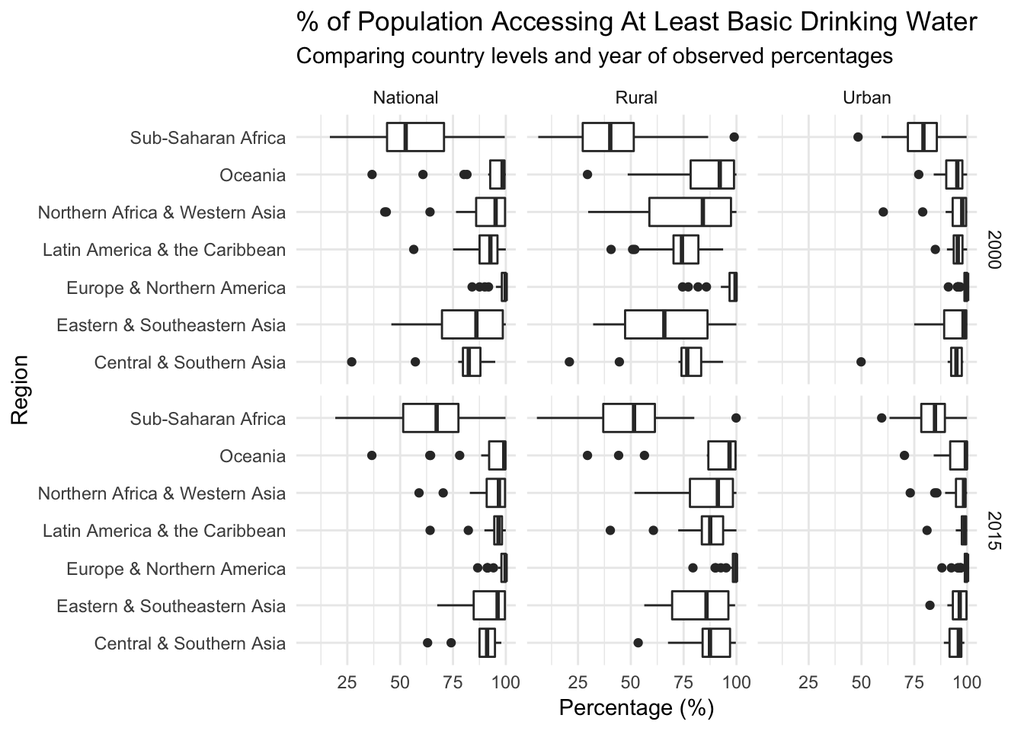

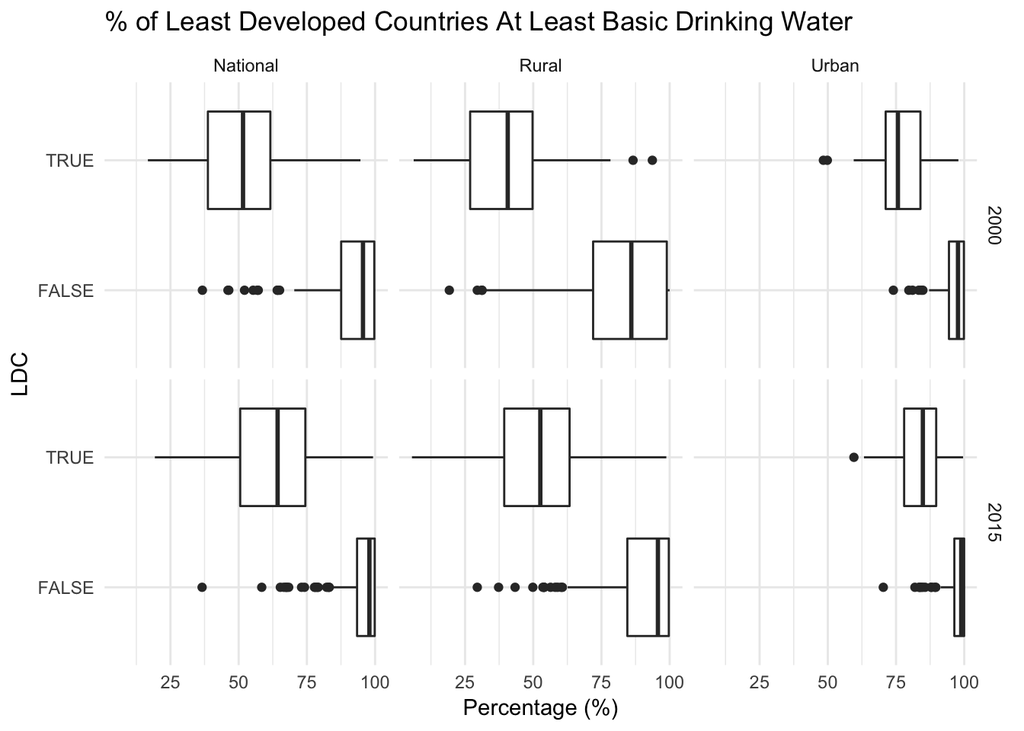

#### National

| National: At Least Basic | World | Central & Southern Asia | Eastern & Southeastern Asia | Europe & Northern America | Latin America & Caribbean | Northern Africa & Western Asia | Oceania | Sub-Saharan Africa | Least Developed Countries | Not LDC |
| --- | --- | --- | --- | --- | --- | --- | --- | --- | --- | --- |
| **2000** |  |  |  |  |  |  |  |  |  |  |
| Minimum | 16.73 | 27.07 | 45.83 | 84.06 | 56.42 | 42.71 | 36.71 | 16.73 | 16.73 | 36.71 |
| Maximum | 100 | 94.99 | 100.00 | 100.00 | 100.00 | 100.00 | 100.00 | 99.50 | 94.65 | 100 |
| Median (QR1,QR3) | 91.89 (74.94, 99.18) | 82.48 (79.71, 87.98) | 86.09 (69.79, 98.57) | 99.94 (98.11, 100.00) | 92.69 (87.57, 96.06) | 95.17 (85.96, 99.64) | 98.49 (92.61, 99.40) | 52.62 (43.79, 70.75) | 51.60 (38.72, 61.62) | 95.58 (87.58, 99.72) |
| IQR | 24.25 | 8.27 | 28.79 | 1.89 | 8.49 | 13.67 | 6.79 | 26.96 | 22.9 | 12.14 |
| Mean (SD) | 82.40 ± 21.42 | 78.97 ± 17.52 | 81.57 ± 19.36 | 98.31 ± 3.45 | 90.30 ± 8.41 | 87.64 ± 17.08 | 91.10 ± 15.61 | 55.43 ± 20.33 | 51.50 ± 18.79 | 90.98 ± 12.24 |

| National: At Least Basic | World | Central & Southern Asia | Eastern & Southeastern Asia | Europe & Northern America | Latin America & Caribbean | Northern Africa & Western Asia | Oceania | Sub-Saharan Africa | Least Developed Countries | Not LDC |
| --- | --- | --- | --- | --- | --- | --- | --- | --- | --- | --- |
| **2015** |  |  |  |  |  |  |  |  |  |  |
| Minimum | 19.29 | 62.98 | 67.54 | 86.69 | 64.17 | 58.93 | 36.60 | 19.29 | 19.29 | 36.6 |
| Maximum | 100 | 97.88 | 100.00 | 100.00 | 100.00 | 100.00 | 100.00 | 99.87 | 99.26 | 100 |
| Median (QR1,QR3) | 96.43 (83.09, 99.59) | 91.15 (87.56, 94.87) | 96.13 (84.80, 99.57) | 99.90 (97.92, 100.00) | 96.55 (94.53, 98.20) | 96.75 (90.94, 99.63) | 99.26 (92.11, 99.79) | 67.27 (51.43, 77.58) | 64.28 (50.57, 74.44) | 97.93 (93.41, 99.87) |
| IQR | 16.5 | 7.31 | 14.78 | 2.08 | 3.68 | 8.69 | 7.68 | 26.15 | 23.87 | 6.47 |
| Mean (SD) | 88.07 ± 16.79 | 88.75 ± 10.02 | 90.88 ± 10.97 | 98.48 ± 2.79 | 95.43 ± 5.72 | 92.85 ± 10.13 | 91.49 ± 16.08 | 65.32 ± 17.77 | 63.78 ± 17.11 | 94.59 ± 8.89 |

OUTLIERS

**2000**

- *Central & Southern Asia*: Afghanistan (27.07), Tajikistan (57.18)
- *Eastern & Southeastern Asia*: NONE
- *Europe & Northern America*: Republic of Moldova (84.06), Albania (87.58), Lithuania (90.05), Serbia (91.82)
- *Latin America & the Caribbean*: Haiti (56.42)
- *Northern Africa & Western Asia*: Yemen (42.71), Sudan (43.43), Morocco (64.13)
- *Oceania*: Papua New Guinea (36.71), Kiribati (60.79), Solomon Islands (80.23), Vanuatu (81.61)
- *Sub-Saharan Africa*: NONE

**2015**

- *Central & Southern Asia*: Afghanistan (62.98), Tajikistan (74.14)
- *Eastern & Southeastern Asia*: NONE
- *Europe & Northern America*: Republic of Moldova (86.69), Serbia (91.18), Albania (91.39), Saint Pierre and Miquelon (91.4), Channel Islands (94.15)
- *Latin America & the Caribbean*: Haiti (64.17), Nicaragua (82.26)
- *Northern Africa & Western Asia*: Sudan (58.93), Yemen (70.36)
- *Oceania*: Papua New Guinea (36.6), Solomon Islands (64.03), Kiribati (64.39), Marshall Islands (78.16)
- *Sub-Saharan Africa*: NONE

#### Rural

| Rural: At Least Basic | World | Central & Southern Asia | Eastern & Southeastern Asia | Europe & Northern America | Latin America & Caribbean | Northern Africa & Western Asia | Oceania | Sub-Saharan Africa | Least Developed Countries | Not LDC |
| --- | --- | --- | --- | --- | --- | --- | --- | --- | --- | --- |
| **2000** |  |  |  |  |  |  |  |  |  |  |
| Minimum | 6.18 | 20.92 | 32.16 | 74.50 | 40.65 | 29.79 | 29.48 | 6.18 | 6.18 | 19.24 |
| Maximum | 100 | 93.66 | 99.96 | 100.00 | 93.68 | 100.00 | 100.00 | 98.93 | 93.66 | 100 |
| Median (QR1,QR3) | 77.17 (48.52, 96.64) | 76.70 (73.96, 83.30) | 65.86 (47.29, 86.30) | 99.56 (96.72, 100.00) | 74.20 (70.19, 81.97) | 84.10 (58.77, 97.40) | 92.10 (78.31, 98.83) | 40.27 (27.23, 51.39) | 40.65 (26.87, 49.75) | 85.95 (71.95, 98.96) |
| IQR | 48.13 | 9.33 | 39.01 | 3.28 | 11.78 | 38.62 | 20.52 | 24.17 | 22.88 | 27.02 |
| Mean (SD) | 70.26 ± 27.17 | 73.31 ± 18.81 | 66.94 ± 23.83 | 96.77 ± 6.26 | 72.63 ± 13.18 | 75.81 ± 25.11 | 83.64 ± 21.77 | 40.51 ± 19.99 | 41.39 ± 21.39 | 81.08 ± 20.37 |

| Rural: At Least Basic | World | Central & Southern Asia | Eastern & Southeastern Asia | Europe & Northern America | Latin America & Caribbean | Northern Africa & Western Asia | Oceania | Sub-Saharan Africa | Least Developed Countries | Not LDC |
| --- | --- | --- | --- | --- | --- | --- | --- | --- | --- | --- |
| **2015** |  |  |  |  |  |  |  |  |  |  |
| Minimum | 5.54 | 53.48 | 56.36 | 79.39 | 40.29 | 51.71 | 29.48 | 5.54 | 5.54 | 29.48 |
| Maximum | 100 | 99.70 | 99.35 | 100.00 | 100.00 | 100.00 | 100.00 | 99.83 | 98.78 | 100 |
| Median (QR1,QR3) | 87.65 (60.38, 99.04) | 87.46 (83.97, 96.96) | 85.82 (69.55, 96.18) | 99.78 (98.30, 100.00) | 87.57 (83.60, 93.69) | 91.19 (77.97, 98.31) | 96.71 (86.68, 99.54) | 51.51 (36.94, 61.40) | 52.60 (39.36, 63.32) | 95.70 (84.49, 99.69) |
| IQR | 38.66 | 12.99 | 26.63 | 1.70 | 10.08 | 20.34 | 12.86 | 24.46 | 23.95 | 15.2 |
| Mean (SD) | 78.77 ± 23.29 | 86.06 ± 13.06 | 81.38 ± 15.84 | 98.17 ± 3.88 | 86.06 ± 13.03 | 85.88 ± 15.08 | 85.36 ± 22.82 | 49.84 ± 17.40 | 53.09 ± 20.88 | 88.55 ± 15.40 |

OUTLIERS

**2000**

- *Central & Southern Asia*: Afghanistan (20.92), Tajikistan (44.57)
- *Eastern & Southeastern Asia*: NONE
- *Europe & Northern America*: Republic of Moldova (74.5), Lithuania (77.17), Albania (81.83), Russian Federation (85.78)
- *Latin America & the Caribbean*: Haiti (40.65), Peru (50.85), Paraguay (51.89)
- *Northern Africa & Western Asia*: NONE
- *Oceania*: Papua New Guinea (29.48)
- *Sub-Saharan Africa*: NONE

**2015**

- *Central & Southern Asia*: Afghanistan (53.48)
- *Eastern & Southeastern Asia*: NONE
- *Europe & Northern America*: Republic of Moldova (79.39), Albania (89.88), Russian Federation (90.22), Lithuania (92.6), Serbia (95.08)
- *Latin America & the Caribbean*: Haiti (40.29), Nicaragua (60.69)
- *Northern Africa & Western Asia*: NONE
- *Oceania*: Papua New Guinea (29.48), Kiribati (44.22), Solomon Islands (56.44)
- *Sub-Saharan Africa*: NONE

#### Urban

| Urban: At Least Basic | World | Central & Southern Asia | Eastern & Southeastern Asia | Europe & Northern America | Latin America & Caribbean | Northern Africa & Western Asia | Oceania | Sub-Saharan Africa | Least Developed Countries | Not LDC |
| --- | --- | --- | --- | --- | --- | --- | --- | --- | --- | --- |
| **2000** |  |  |  |  |  |  |  |  |  |  |
| Minimum | 48.37 | 49.81 | 74.92 | 91.11 | 84.94 | 60.32 | 77.09 | 48.37 | 48.37 | 74.02 |
| Maximum | 100 | 98.18 | 100.00 | 100.00 | 100.00 | 100.00 | 100.00 | 99.75 | 97.85 | 100 |
| Median (QR1,QR3) | 95.38 (86.22, 99.46) | 94.94 (92.42, 97.47) | 98.31 (89.12, 99.60) | 100.00 (98.72, 100.00) | 95.57 (93.64, 97.80) | 97.67 (93.15, 99.50) | 95.34 (90.11, 97.75) | 79.32 (71.95, 85.65) | 75.69 (71.20, 83.95) | 97.71 (94.40, 99.88) |
| IQR | 13.25 | 5.05 | 10.48 | 1.28 | 4.16 | 6.35 | 7.64 | 13.70 | 12.75 | 5.48 |
| Mean (SD) | 91.03 ± 11.06 | 91.85 ± 12.34 | 92.19 ± 9.47 | 99.01 ± 1.86 | 95.31 ± 3.34 | 93.85 ± 10.16 | 93.21 ± 6.92 | 78.92 ± 10.69 | 76.46 ± 11.02 | 96.12 ± 4.77 |

| Urban: At Least Basic | World | Central & Southern Asia | Eastern & Southeastern Asia | Europe & Northern America | Latin America & Caribbean | Northern Africa & Western Asia | Oceania | Sub-Saharan Africa | Least Developed Countries | Not LDC |
| --- | --- | --- | --- | --- | --- | --- | --- | --- | --- | --- |
| **2015** |  |  |  |  |  |  |  |  |  |  |
| Minimum | 59.56 | 88.98 | 82.40 | 88.06 | 81.02 | 73.08 | 70.33 | 59.56 | 59.56 | 70.33 |
| Maximum | 100 | 98.67 | 100.00 | 100.00 | 100.00 | 100.00 | 100.00 | 99.92 | 99.58 | 100 |
| Median (QR1,QR3) | 97.04 (89.58, 99.70) | 96.07 (91.68, 97.27) | 96.50 (93.23, 99.69) | 99.97 (98.88, 100.00) | 98.82 (97.47, 99.53) | 98.52 (94.71, 99.26) | 99.38 (91.97, 99.92) | 84.78 (78.29, 89.47) | 84.83 (77.97, 89.72) | 98.89 (96.37, 99.97) |
| IQR | 10.13 | 5.59 | 6.46 | 1.12 | 2.06 | 4.55 | 7.95 | 11.17 | 11.75 | 3.59 |
| Mean (SD) | 93.40 ± 8.62 | 94.52 ± 3.41 | 95.76 ± 4.82 | 98.92 ± 2.29 | 97.87 ± 3.56 | 94.78 ± 7.22 | 94.80 ± 8.62 | 83.50 ± 9.05 | 83.40 ± 9.22 | 97.02 ± 4.63 |

OUTLIERS

**2000**

- *Central & Southern Asia*: Afghanistan (49.81)
- *Eastern & Southeastern Asia*: NONE
- *Europe & Northern America*: Serbia (91.11), Republic of Moldova (95.38), Albania (95.62), Ireland (95.71), Lithuania (96.39), Ukraine (96.73)
- *Latin America & the Caribbean*: Haiti (84.94)
- *Northern Africa & Western Asia*: Sudan (60.32), Yemen (78.96)
- *Oceania*: Kiribati (77.09)
- *Sub-Saharan Africa*: Somalia (48.37)

**2015**

- *Central & Southern Asia*: NONE
- *Eastern & Southeastern Asia*: Myanmar (82.4)
- *Europe & Northern America*: Serbia (88.06), Albania (92.52), Republic of Moldova (95.62), The former Yugoslav Republic of Macedonia (95.79), Montenegro (96.7), Ukraine (96.89), Bosnia and Herzegovina (97.04)
- *Latin America & the Caribbean*: Haiti (81.02)
- *Northern Africa & Western Asia*: Sudan (73.08), Yemen (84.66), West Bank and Gaza Strip (85.66)
- *Oceania*: Marshall Islands (70.33)
- *Sub-Saharan Africa*: South Sudan (59.56)

#### Analysis

- The 2000 minimum was in Ethiopia (16.73), a sub-saharan african and least developed country.
- The next four lowest percentage countries were Eritrea (16.83), Somalia, (20.68), Mozambique (22.21), and Afghanistan (27.07).
- The 2015 minimum was in Eritrea (19.29), a sub-saharan african and least developed country.
- The next four lowest percentage countries were Papua New Guinea (36.6), Uganda, (38.92), Ethiopia (39.12), and Somalia (40).
- In 2000, only 52 of the 207 countries were below the 25th percentile (74.94), and 39 of those countries were from the sub-saharan african region.
- In 2015, only 57 of the 227 countries were below the 25th percentile (83.09), and 42 of those countries were from the sub-saharan african region.

# Conclusions

I ended up not completing this project due to the amount of time in between finishing this project and doing school. I wanted to move on and look at other datasets that interested me. However, I’m still proud of the progress I made on this project and still decided it was worth posting.